# Co váží „typický“ savec?

První setkání s daty a popisem jedné proměnné

Publikováno

26. července 2026

Upraveno

4. října 2026

## 1 Vítejte v biostatistice

Biostatistika pomáhá převést biologickou otázku na postup, který lze zkontrolovat: **co jsme pozorovali, co jsme změřili, jak jsme data zobrazili a co z nich smíme tvrdit**. Budeme se opakovaně vracet k cestě:

> biologická otázka → data → graf → model → kontrola → interpretace

V této lekci zůstaneme u prvního statistického kroku: jak poctivě popsat **jednu proměnnouVlastnost zaznamenaná u pozorování, která může mezi pozorováními nabývat různých hodnot, například druh, délka nebo počet.**.

### 1.1 Jak jsou kurz a materiály uspořádány

| Součást | K čemu slouží | Jak s ní pracovat |
| --- | --- | --- |
| Přednáška | Společné přemýšlení nad biologickou otázkou, grafy a interpretací | Hlasujte, porovnávejte vysvětlení a ptejte se, co výsledek skutečně znamená. |
| Praktické cvičení | Samostatná práce s daty a R s podporou vyučujících | Kód zkoušejte, měňte a průběžně vysvětlujte vlastními slovy. |
| Tyto podklady | Úplnější vysvětlení a reprodukovatelné příklady | Čtěte je před výukou nebo se k nim vraťte při opakování. |
| Výstupy v HTML a PDF | Dvě podoby stejného obsahu | HTML nabízí interaktivní prvky; PDF se hodí pro souvislé čtení a poznámky. |

### 1.2 Kde najdete materiály a informace

**Hlavním veřejným rozcestníkem je [web kurzu (HUB)](https://cuni-natur-biostatistics.github.io/).** Na stránce [Materiály](https://cuni-natur-biostatistics.github.io/materialy.html) najdete pro každou zveřejněnou lekci stabilní studentské verze:

| Materiál | Dostupné podoby | K čemu slouží |
| --- | --- | --- |
| Skripta | HTML; PDF pro tisk | Úplnější výklad pro přípravu, samostudium a opakování |
| Prezentace | HTML; PDF pro tisk | Stručnější záznam společné práce na přednášce |
| R skripty | soubory s kódem | Praktická práce s daty v R |
| Data | datové soubory | Data potřebná pro praktickou práci a samostatné procvičování |

### 1.3 Doporučená literatura

K absolvování kurzu **stačí materiály zveřejněné na webu kurzu (HUB)**: skripta, prezentace, R skripty a data. Literatura je nepovinná a hodí se, když chcete látku vidět z jiného úhlu nebo si ji procvičit na dalších příkladech. Požadavky kurzu určují tyto materiály, ne uvedené knihy.

**Knihy**

| Zdroj | K čemu se hodí |
| --- | --- |
| Lepš, J., Šmilauer, P. (2024): *Biostatistika*, 2. přepracované vydání. Nakladatelství Jihočeské univerzity, České Budějovice. ISBN 978-80-7694-066-6. (česky) | Česká učebnice statistiky pro biology s postupy v programech Statistica a R. |
| Crawley, M. J. (2013): *The R Book*, 2. vydání. John Wiley & Sons, Chichester. (anglicky) | Rozsáhlá příručka k R a statistickým postupům v něm. |
| Dalgaard, P.: *Introductory Statistics with R*. Springer. (anglicky) | Stručný úvod do statistiky s ukázkami v R. |

**Online zdroje v angličtině**

| Zdroj | K čemu se hodí |
| --- | --- |
| Wickham, H., Çetinkaya-Rundel, M., Grolemund, G.: [*R for Data Science*](https://r4ds.hadley.nz/), 2. vydání. | Práce s daty a grafy v R. |
| Ismay, C., Kim, A. Y., Valdivia, A.: [*Statistical Inference via Data Science: A ModernDive into R and the Tidyverse*](https://moderndive.com/v2/), 2. vydání. | Statistické myšlení a R krok za krokem. |

Online zdroje mohou používat jiný styl zápisu R kódu než naše materiály nebo pokrývat širší témata. Úplný a aktuální seznam literatury najdete na stránce [Jak pracovat s materiály](https://cuni-natur-biostatistics.github.io/jak-pracovat-s-materialy.html) na webu kurzu (HUB).

Různé kurzové systémy mají odlišné úlohy:

| Systém | K čemu slouží |
| --- | --- |
| **Web kurzu (HUB)** | Aktuální informace o kurzu, rozvrh, pravidla hodnocení, veřejné studijní materiály a archiv semestrů |
| **SIS** | Zápis do předmětu a skupin, termíny zkoušek a oficiální studijní evidence |
| **Moodle** | Testy, zadání, odevzdávání, individuální výsledky a oznámení určená zapsaným studentům |

### 1.4 Účast, zápočet a zkouška

Účast na přednáškách a praktických cvičeních je dobrovolná. Ve výuce získáte vysvětlení, podporu a zpětnou vazbu; při samostudiu najdete požadované znalosti ve skriptech a R skriptech. **Stejné kompetence však musí prokázat každý.**

- **Praktický zápočet** ověřuje, zda dokážete samostatně provést a vysvětlit základní analýzu malého datasetu v R.
- **Závěrečná zkouška** ověřuje porozumění analytickým rozhodnutím, interpretaci, diagnostice a nejistotě, nikoli psaní syntaxe zpaměti.

**PoznámkaAI při učení a hodnocení**

Při učení můžete AI používat. U zápočtu a zkoušky pracujete samostatně bez internetu a AI.

Aktuální [pravidla hodnocení](https://cuni-natur-biostatistics.github.io/hodnoceni.html) jsou uvedena na webu kurzu (HUB). Termíny zkoušek a zápis na ně jsou v SIS. Termíny praktického zápočtu, odevzdávání, individuální výsledky a neveřejné organizační pokyny jsou v Moodle.

## 2 Jak číst skripta

Tento dokument vznikl v Quarto, ale pro jeho čtení nemusíte Quarto znát ani instalovat. Stejný obsah dostáváte jako webovou stránku (HTML) a jako PDF. Liší se hlavně způsob, jak se v něm pohybujete.

### 2.1 Doporučený způsob čtení

1. Nejdříve si přečtěte **výsledky učení**. Říkají, co byste po dokončení kapitoly měli umět.
2. U otázky, hlasování nebo úkolu se zastavte a zkuste odpovědět dříve, než budete pokračovat.
3. Graf nebo tabulku nejprve sami popište. Teprve potom čtěte vysvětlení pod nimi.
4. Kód nemusíte memorovat. Sledujte, jaká data do něj vstupují, co s nimi příkaz dělá a jaký výsledek vrací.
5. Na konci se vraťte ke shrnutí a ověřte si, zda už dokážete vysvětlit hlavní myšlenky vlastními slovy.

### 2.2 HTML a PDF

Následující blok je zároveň ukázkou **záložek** (anglicky *tabs*, technicky *tabset*). V HTML mezi záložkami přepínáte kliknutím. V PDF jsou jejich obsahy vytištěné postupně za sebou.

**HTML**

- Obsah na okraji stránky umožňuje přejít přímo do vybrané části.
- Projděte všechny záložky; současně je viditelná jen jedna.
- Rámeček s šipkou lze rozbalit a zase sbalit.
- U podtrženého odborného pojmu se po najetí kurzorem zobrazí stručné vysvětlení.
- U delšího bloku kódu se po najetí objeví tlačítko pro jeho zkopírování.

**PDF**

- K orientaci slouží obsah, nadpisy a čísla stránek.
- Obsah všech záložek je vytištěný postupně, takže žádná část nechybí.
- Sbalitelné rámečky jsou rozbalené. U odpovědi se proto zastavte ještě před jejím přečtením.
- Význam odborných pojmů najdete v odkazovaném online slovníku.

### 2.3 Co znamenají rámečky a další značky

| Značka | Jak s ní pracovat |
| --- | --- |
| **Důležité** | Hlavní pojem nebo závěr, který byste si měli odnést. |
| **Pozor** | Častá chyba nebo omyl. Zkontrolujte, že rozumíte, proč je daný postup problematický. |
| **Poznámka** | Podpůrné vysvětlení, příklad nebo kontext k hlavnímu výkladu. |
| **Doplňující** | Volitelná technická či rozšiřující informace. Při prvním čtení ji můžete přeskočit. |
| **Otázka**, **Hlasování**, **Úkol** | Výzva k vlastní odpovědi nebo činnosti. Nejdříve se rozhodněte sami. |
| **Odpověď** | Kontrola po vlastním pokusu. V HTML ji otevřete kliknutím; v PDF je vytištěná. |
| Blok kódu a jeho výstup | Reprodukovatelný záznam postupu: co jsme zadali počítači a co počítač vrátil. |
| Podtržený odborný pojem | Odkaz na stručnou definici v online slovníku. |

Význam nese především nadpis rámečku. Barva pomáhá s orientací, ale není nutné si ji pamatovat.

**TipDoplňující: rozbalovací rámeček**

Tento rámeček obsahuje volitelné rozšíření. V HTML jej můžete rozbalit; v PDF je vytištěný celý.

### 2.4 Jak číst kód

Každý řádek kódu, který vytváří výsledek, je v těchto materiálech viditelný, abyste mohli zkontrolovat, odkud se číslo nebo graf vzaly. Kód si nemusíte pamatovat. Při čtení se ptejte: **Jaká data vstupují? Co příkaz dělá? Jakou odpověď dostáváme?** Řádky začínající znakem `#` jsou komentáře pro čtenáře; počítač je nevykonává.

## 3 Výsledky učení

Po prostudování materiálů dokážete:

- vysvětlit, co v tabulce představuje jeden řádek, vytvořit z několika měření vektor v R a zkontrolovat jej pomocí `length()` a `head()`;
- přečíst bodový graf, histogramGraf zobrazující rozdělení hodnot numerické proměnné: hodnoty jsou seřazeny do tříd, výška sloupce udává četnost v dané třídě., graf hustoty, sloupcový grafGraf kategoriální proměnné, v němž výška nebo délka oddělených sloupců představuje četnosti, podíly nebo jiný souhrn kategorií. a krabicový grafGraf, jehož krabice sahá od Q1 do Q3 a obsahuje medián; vousy vymezují hodnoty podle zvoleného pravidla a body za nimi upozorňují na možná odlehlá pozorování. a popsat, co každý z nich ukazuje a skrývá;
- vysvětlit, proč data zobrazujeme dříve, než je shrneme jedním číslem;
- najít a interpretovat průměrSoučet hodnot vydělený jejich počtem; nejběžnější míra polohy (střední hodnoty)., mediánHodnota rozdělující seřazená data na dvě stejně početné poloviny; 50. percentil., kvartilyHodnota, pod níž leží určený podíl seřazených dat; medián je 50% kvantil., IQRRozdíl mezi 3. kvartilem (Q3) a 1. kvartilem (Q1); pokrývá prostředních 50 % dat a je robustní vůči odlehlým pozorováním., minimum, maximum a směrodatnou odchylkuOdmocnina rozptylu; vyjadřuje průměrnou vzdálenost hodnot od průměru ve stejných jednotkách jako původní data. v číslech i na grafu;
- rozlišit spojitouNumerická proměnná, která může v principu nabývat libovolné hodnoty v určitém intervalu, například délka, hmotnost nebo čas., diskrétníNumerická proměnná s oddělenými, spočetnými možnými hodnotami, například počet jedinců nebo počet událostí., nominálníKategoriální proměnná, jejíž kategorie nemají přirozené pořadí, například druh, ostrov nebo barva. a ordinálníKategoriální proměnná s přirozeně seřazenými kategoriemi, jejichž vzájemné vzdálenosti však nemusí být stejné nebo známé. proměnnouVlastnost zaznamenaná u pozorování, která může mezi pozorováními nabývat různých hodnot, například druh, délka nebo počet. a vybrat pro ni smysluplný první graf a shrnutí.

## 4 Datová detektivka: kolik váží „typický“ savec?

V tabulce máme hmotnost 83 druhů savců. Chceme odpovědět na zdánlivě jednoduchou otázku:

> **Kolik váží „typický“ savec v této tabulce?**

Představte si, že ze stejných dat vyšly dva smyšlené novinové články.

**QuestionSmyšlený titulek A**

**Vědci spočítali: „Průměrný savec váží 166 kg.“**

**QuestionSmyšlený titulek B**

**Jiná analýza stejných dat tvrdí: „Běžný savec váží jen 1,67 kg.“**

### 4.1 Hlasování

Který titulek je podle vás nejpravděpodobněji správný?

- 1. Správný je pouze titulek A.
- 2. Správný je pouze titulek B.
- 3. Obě čísla mohou být vypočtena správně.
- 4. Bez dalších informací nelze rozhodnout.

Než budete pokračovat, vyberte jednu odpověď a napište si **jednu větu**, která ji zdůvodňuje. Zatím nepotřebujete znát názvy výpočtů. Potřebujete pouze rozpoznat, jaké informace vám chybějí.

**DůležitéOdpověď zatím odložíme**

Nejdříve se naučíme sledovat cestu od měření přes tabulku a graf až k číselnému shrnutí. K oběma titulkům se vrátíme ve chvíli, kdy budeme umět posoudit nejen výsledek výpočtu, ale také tvar dat.

## 5 Od měření k tabulce a vektoru

Výzkumníci studovali spánkové vzorce savců a zaznamenali, že gepard spí **12,1 hodiny za den**. Jedno takové pozorování můžeme zapsat jako jeden řádek tabulky: název druhu, sledovanou proměnnou, jednotku a naměřenou hodnotu.

Když podobná pozorování spojíme pro více druhů, vznikne datová tabulka. Dataset `msleep` obsahuje údaje o spánku a tělesné hmotnosti různých druhů savců a vychází z publikovaných biologických údajů. Každý řádek představuje **jeden zastoupený druh**, nikoli jednoho jednotlivého savce.

Představme si terénní nebo laboratorní práci, ze které taková tabulka vzniká. Výzkumníci pro každý druh shromáždí nebo převezmou měření, zapíší název druhu, jednotku a hodnotu a přidají je jako nový řádek. Naší jednotkou pozorováníEntita nebo děj, o kterém jedno pozorování nese informace, například jedinec, plocha, vzorek vody nebo jedna erupce. je zastoupený druh. My začneme jedinou proměnnouVlastnost zaznamenaná u pozorování, která může mezi pozorováními nabývat různých hodnot, například druh, délka nebo počet.: **celkovou dobou spánku za den v hodinách** (`sleep_total`).

### 5.1 Čtyři skutečné záznamy

Podívejme se na první čtyři řádky. Hodnota v posledním sloupci je číslo, které by výzkumník zapsal do tabulky.

| Druh (species) | Celkový spánek za den (sleep total; h) |
| --- | --- |
| Cheetah | 12.1 |
| Owl monkey | 17.0 |
| Mountain beaver | 14.4 |
| Greater short-tailed shrew | 14.9 |

### 5.2 Stejné hodnoty jako vektor v R

**Vektor** je uspořádaná řada hodnot stejného základního typu. Čtyři hodnoty z tabulky můžeme do R zapsat pomocí funkce `c()`:

```r
vec_spanek_ukazka <-
  c(
    12.1, # Cheetah
    17.0, # Owl monkey
    14.4, # Mountain beaver
    14.9  # Greater short-tailed shrew
  )

vec_spanek_ukazka
```

```
[1] 12.1 17.0 14.4 14.9
```

Každá hodnota má stejný význam i jednotku: počet hodin spánku za den pro jeden zastoupený druh.

U celé tabulky nemusíme 83 čísel opisovat ručně. Vybereme sloupec `sleep_total` přímo z datového rámce:

```r
# Vybereme jeden sloupec z původní tabulky.
vec_spanek_h <-
  ggplot2::msleep[["sleep_total"]]
```

### 5.3 První kontrola vektoru

Než začneme počítat nebo kreslit, zkontrolujeme dvě jednoduché věci:

1. **Kolik hodnot máme?**
2. **Vypadají první hodnoty jako očekávaná měření v hodinách?**

```r
length(vec_spanek_h)
```

```
[1] 83
```

```r
head(
  x = vec_spanek_h,
  n = 10
)
```

```
 [1] 12.1 17.0 14.4 14.9  4.0 14.4  8.7  7.0 10.1  3.0
```

`length()` potvrzuje počet hodnot. `head()` ukazuje začátek vektoru, takže rychle odhalíme například omylem načtený textový sloupec nebo nečekané jednotky. Argument `n = 10` říká, že chceme zobrazit **prvních deset hodnot**; jiné číslo za `n =` by změnilo počet zobrazených hodnot. Ani jedna kontrola ale ještě neukazuje tvar celého souboru hodnot.

**TipDoplňující: integer a double jako dva způsoby uložení čísel**

R ukládá `5L` jako celé číslo typu `integer` a `5` jako číslo typu `double`:

```r
typeof(5L) # "integer"
typeof(5)  # "double"
```

Jde o **technický způsob uložení čísla v počítači**, nikoli automaticky o statistický typ proměnnéVlastnost zaznamenaná u pozorování, která může mezi pozorováními nabývat různých hodnot, například druh, délka nebo počet.. Zaokrouhlená tělesná hmotnost `70` může být spojité měření uložené jako `double`; počet pěti mláďat může být diskrétní proměnná uložená jako `integer`. O statistickém typu rozhoduje význam hodnot.

### 5.4 Jak vypadá celý datový rámec?

Vektor drží jednu proměnnou. Původní datový rámec drží více proměnných vedle sebe. Každý řádek stále představuje jeden druh.

```r
# Počet řádků a sloupců původních dat.
dim(ggplot2::msleep)
```

```
[1] 83 11
```

```r
# Prvních šest řádků původních dat.
head(ggplot2::msleep, n = 6)
```

```
# A tibble: 6 × 11
  name    genus vore  order conservation sleep_total sleep_rem sleep_cycle awake
  <chr>   <chr> <chr> <chr> <chr>              <dbl>     <dbl>       <dbl> <dbl>
1 Cheetah Acin… carni Carn… lc                  12.1      NA        NA      11.9
2 Owl mo… Aotus omni  Prim… <NA>                17         1.8      NA       7
3 Mounta… Aplo… herbi Rode… nt                  14.4       2.4      NA       9.6
4 Greate… Blar… omni  Sori… lc                  14.9       2.3       0.133   9.1
5 Cow     Bos   herbi Arti… domesticated         4         0.7       0.667  20
6 Three-… Brad… herbi Pilo… <NA>                14.4       2.2       0.767   9.6
# ℹ 2 more variables: brainwt <dbl>, bodywt <dbl>
```

| Otázka | Odpověď pro `msleep` |
| --- | --- |
| Co představuje jeden řádek? | jeden zastoupený druh savce |
| Co představuje sloupec `sleep_total`? | celkovou dobu spánku za den v hodinách |
| Co představuje sloupec `bodywt`? | tělesnou hmotnost druhu v kilogramech |
| Je jeden řádek jeden jedinec? | ne; druh je zde shrnut jednou hodnotou |

**PoznámkaDruh není jedinec**

Řádek reprezentuje hodnotu vybranou pro **druh**. Slon africký a drobný rejsek mají v tabulce každý právě jeden řádek. Výsledek proto popisuje zastoupené druhy, nikoli četnostPočet výskytů určité hodnoty nebo kategorie v datové sadě; pro kategoriální proměnné je četnost základní deskriptivní statistikou. nebo hmotnost všech savčích jedinců na Zemi.

**TipDoplňující: odkud data pocházejí a co v nich chybí**

Dataset `msleep` má podle [dokumentace balíčku ggplot2](https://ggplot2.tidyverse.org/reference/msleep.html) 83 řádků a 11 proměnnýchVlastnost zaznamenaná u pozorování, která může mezi pozorováními nabývat různých hodnot, například druh, délka nebo počet.. Údaje o spánku a hmotnosti vycházejí z práce Savage a West (2007), [A quantitative, theoretical framework for understanding mammalian sleep](https://pubmed.ncbi.nlm.nih.gov/17215372/). Dokumentace uvádí, že taxonomický řád, stav ochrany a typ potravy byly doplněny z Wikipedie.

Ne všechny buňky jsou vyplněné: v celé tabulce chybí 136 hodnot. Celková doba spánku a tělesná hmotnost jsou úplné, ale například stav ochrany chybí u 29 druhů a typ potravy u 7 druhů. Chybějící hodnota není nula; znamená, že údaj v tabulce nemáme.

**TipDoplňující: výběr není celá populace**

VýběrSoubor pozorování, z něhož počítáme statistiky a pomocí něhož se snažíme popsat širší populaci nebo proces. je soubor pozorování, která máme skutečně k dispozici. Cílová populace je širší celek, o kterém bychom chtěli něco říct. Dataset `msleep` obsahuje zastoupené druhy savců, ale není automaticky náhodným průřezem všech savců ani všech jedinců. PrůměrSoučet hodnot vydělený jejich počtem; nejběžnější míra polohy (střední hodnoty)., mediánHodnota rozdělující seřazená data na dvě stejně početné poloviny; 50. percentil. nebo SDOdmocnina rozptylu; vyjadřuje průměrnou vzdálenost hodnot od průměru ve stejných jednotkách jako původní data. proto nejprve přesně popisují tento soubor; možnost zobecnění závisí také na tom, jak byly druhy vybrány a jak vznikly jejich souhrnné hodnoty.

Dvě tabulky mohou mít stejný počet řádků a stejně přesně vypočtené statistiky, ale různou vypovídací hodnotu. Pokud v jedné chybějí například málo prozkoumané noční druhy, samotný výpočet tuto nerovnováhu neopraví. V lekci o nejistotěRozsah, v němž nevíme přesnou hodnotu parametru kvůli omezenému a variabilnímu vzorku; kvantifikuje se pomocí intervalů spolehlivosti nebo směrodatných chyb. se vrátíme k odhadu z jednoho výběru; později budeme řešit také situace, kdy řádky nepředstavují nezávislé informační jednotky.

## 6 Vizualizace dat: nejdříve se podívejte

Samotný výpis 83 hodnot se čte obtížně. Graf uspořádá hodnoty podle jejich velikosti a dovolí nám vidět rozděleníPopis toho, jaké hodnoty proměnná nabývá a jak často se vyskytují; může jít o pozorované rozdělení dat nebo o teoretické pravděpodobnostní rozdělení.: kde se hodnoty hromadí, jak široce jsou rozptýlené a zda některé leží stranou.

### 6.1 Proč začínáme grafem?

Než začneme počítat souhrnná čísla, je dobrým obecným pravidlem **nejdříve zobrazit jednotlivé hodnoty**. Graf může odhalit shluky, mezery, asymetrii nebo hodnoty daleko od ostatních. Teprve potom dokážeme posoudit, který číselný popis bude pro daná data smysluplný.

**UpozorněníNikdy nepracujte jen s čísly bez grafu**

Samotný výpis hodnot se čte obtížně a souhrnné číslo část informace vždy skryje. **Graf není ozdoba výsledku. Je to první kontrola toho, co se číselný popis chystá zjednodušit.**

### 6.2 Bodový graf

**Bodový graf (anglicky *dot plot*; zde uspořádaný jako *beeswarm plot*)** zobrazuje každou hodnotu jako samostatný bod. Body jsou mírně posunuté nahoru a dolů, aby se nepřekrývaly a lépe využily plochu grafu.

*Kolik druhů představuje jeden bod? Kde leží nejkratší a nejdelší doba spánku?*

**Graf**

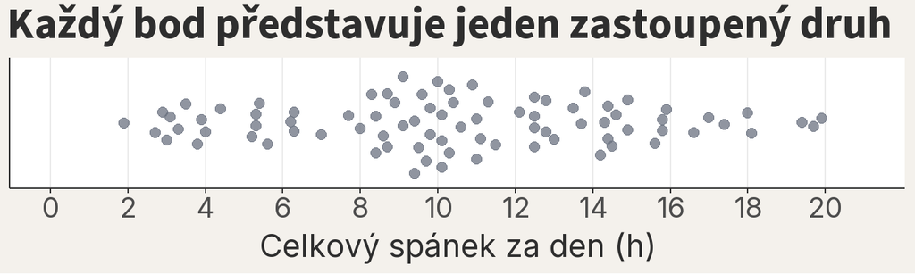

**Kód v R**

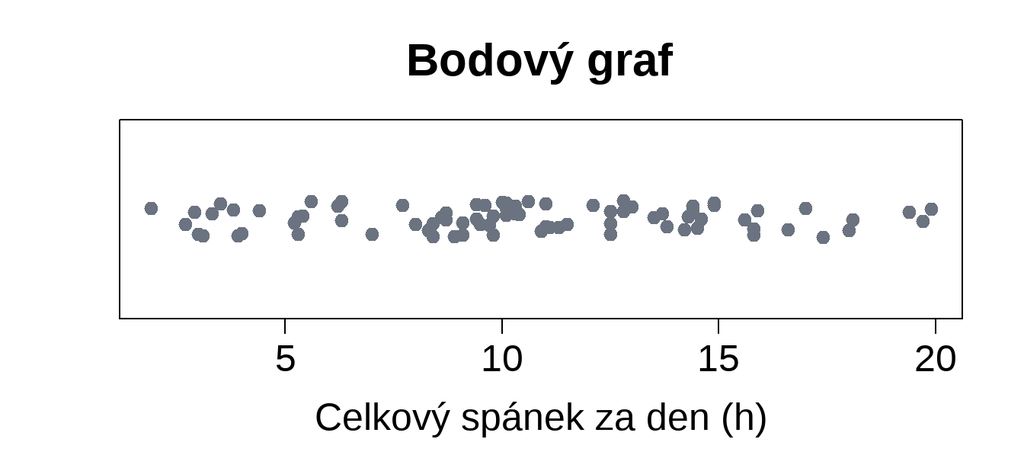

```r
# Zobrazíme každou hodnotu jako jeden bod.
stripchart(
  x = vec_spanek_h,
  method = "jitter",
  jitter = 0.25,
  pch = 19,
  cex = 1.2,
  col = "#6B7280",
  xlab = "Celkový spánek za den (h)",
  main = "Bodový graf"
)
```

Výhoda bodového grafu je úplnost: žádná hodnota nezmizí. Nevýhodou je, že u velkých datových souborů se může mnoho bodů překrývat.

### 6.3 Hodnoty seskupené do intervalů

HistogramGraf zobrazující rozdělení hodnot numerické proměnné: hodnoty jsou seřazeny do tříd, výška sloupce udává četnost v dané třídě. seskupuje číselné hodnoty do navazujících intervalů neboli **košů** (anglicky *bins*). Výška sloupce ukazuje četnostPočet výskytů určité hodnoty nebo kategorie v datové sadě; pro kategoriální proměnné je četnost základní deskriptivní statistikou. hodnot v daném koši.

*Které rozmezí spánku obsahuje nejvíce druhů? Co už z histogramu nedokážete vyčíst o jednotlivém druhu?*

**Graf**

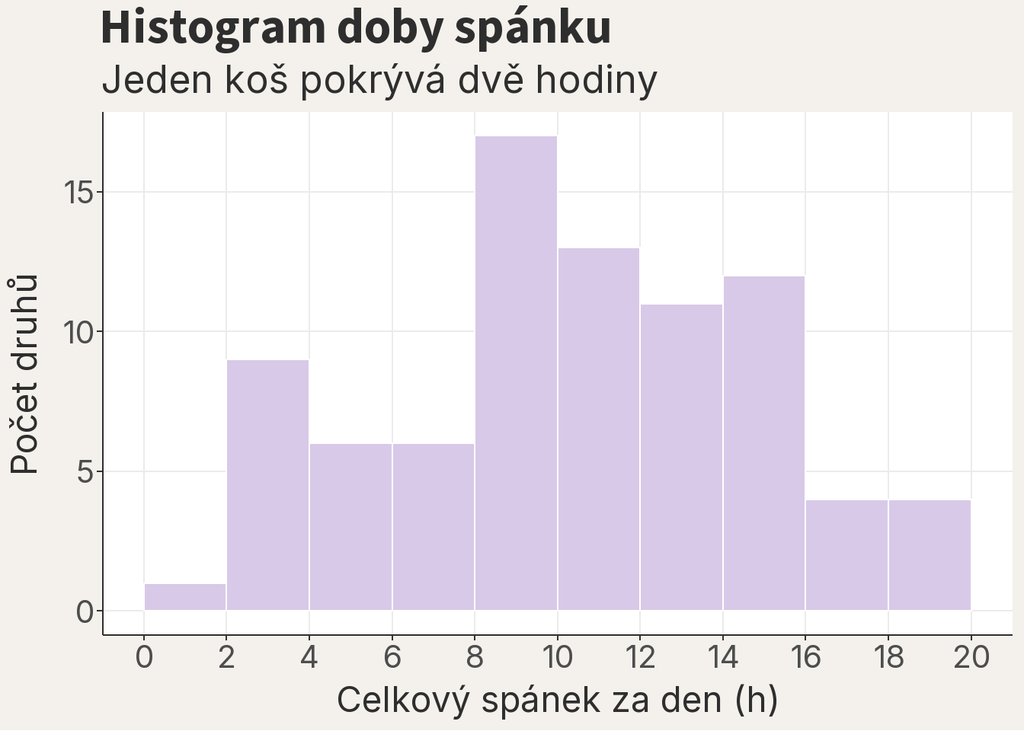

**Kód v R**

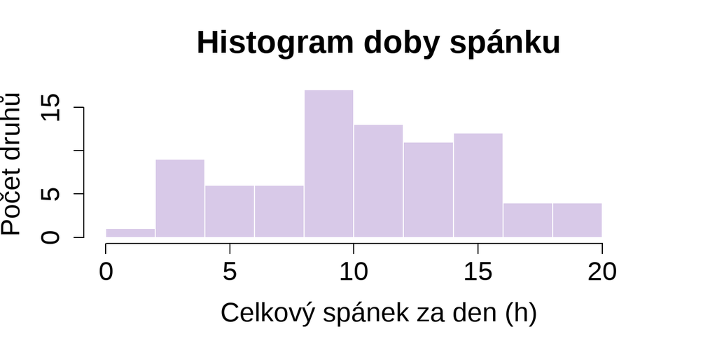

```r
# Rozdělíme osu na intervaly široké dvě hodiny.
hist(
  x = vec_spanek_h,
  breaks = seq(
    from = 0,
    to = 22,
    by = 2
  ),
  col = "#D8C9E8",
  border = "white",
  xlab = "Celkový spánek za den (h)",
  ylab = "Počet druhů",
  main = "Histogram doby spánku"
)
```

**TipDoplňující: jak volit šířku koše?**

Volba šířky koše (anglicky *bin width*) mění míru detailu, ale nemění původní hodnoty. Příliš úzké koše vytvoří zubatý graf; příliš široké koše mohou skrýt důležitý tvar.

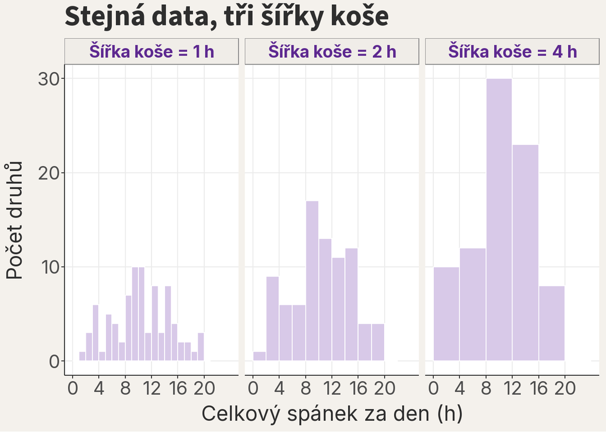

Praktický postup není hledat jedinou „správnou“ šířku. Vyzkoušejte několik rozumných možností a ověřte, zda hlavní interpretace nezávisí na jednom nastavení.

### 6.4 Graf hustoty

**Graf hustoty (anglicky *density plot*)** je vyhlazený pohled na tvar číselných hodnot. Neukazuje počty druhů; osa *y* vyjadřuje hustotu. Křivka je proto vhodná pro porovnávání tvaru, ale méně vhodná pro čtení konkrétních četností.

*Kde má křivka vrchol? Odpovídá tato oblast nejvyšším sloupcům histogramu?*

**Graf**

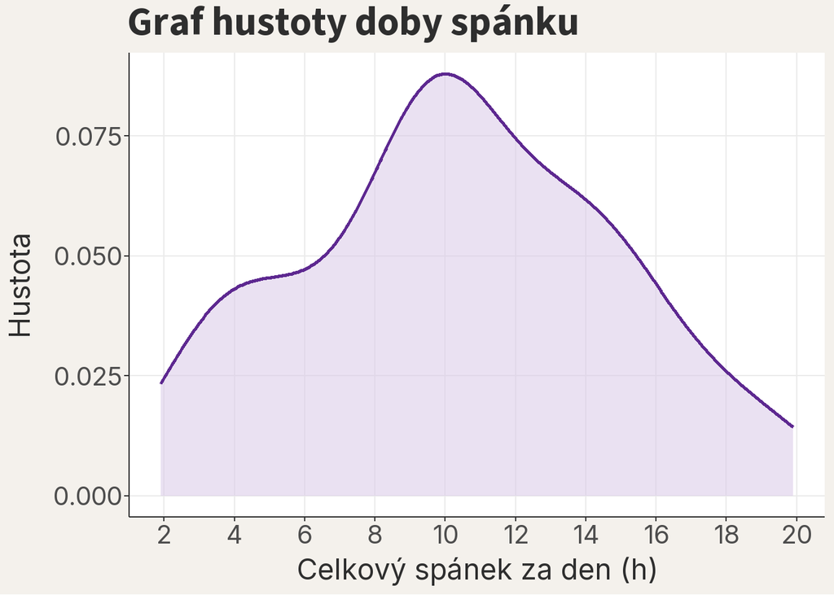

**Kód v R**

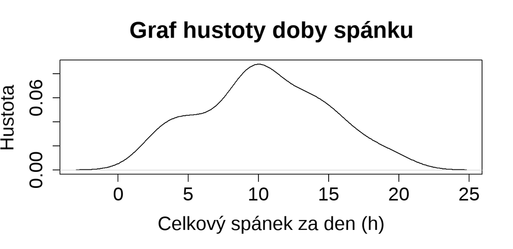

```r
# Odhadneme vyhlazenou hustotu hodnot.
hustota_spanku <-
  density(
    x = vec_spanek_h
  )

plot(
  x = hustota_spanku,
  xlab = "Celkový spánek za den (h)",
  ylab = "Hustota",
  main = "Graf hustoty doby spánku"
)
```

### 6.5 Tři pohledy na tutéž proměnnou

| Graf | Co zachovává | Co skrývá nebo mění |
| --- | --- | --- |
| Bodový graf (*dot/beeswarm plot*) | každou jednotlivou hodnotu | při velkém počtu hodnot může být přeplněný |
| Histogram (*histogram*) | četnosti v intervalech a celkový tvar | přesné hodnoty; vzhled závisí na šířce koše |
| Graf hustoty (*density plot*) | hladký tvar rozdělení | konkrétní počty a jednotlivé hodnoty |

Žádný z těchto grafů není automaticky nejlepší. Vybíráme podle otázky a podle toho, co potřebujeme čtenáři ukázat.

## 7 Deskriptivní statistiky: čísla, která patří ke grafu

Graf ukazuje celý tvar dat. Někdy ale potřebujeme také několik **srovnatelných čísel**: například do tabulky výsledků nebo do jedné věty v článku. **Deskriptivní statistiky** shrnou:

- **polohu** hodnot: kde leží jejich střed nebo okraje;
- **variabilituObecný termín pro rozsah, v němž se hodnoty proměnné liší od sebe navzájem; kvantifikuje se pomocí rozptylu, SD, IQR nebo rozsahu.**: jak moc se hodnoty liší.

Souhrnné číslo nikdy nenahrazuje graf. Čteme je společně.

### 7.1 Malý skutečný příklad

Pro ruční výpočty použijeme devět známých druhů z `msleep`. Každý řádek stále představuje druh a hodnotou je celkový spánek za den v hodinách.

| Druh | Původní název (name) | Spánek za den (h) |
| --- | --- | --- |
| kůň | Horse | 2.9 |
| ovce | Sheep | 3.8 |
| kráva | Cow | 4.0 |
| člověk | Human | 8.0 |
| králík | Rabbit | 8.4 |
| prase | Pig | 9.1 |
| šimpanz | Chimpanzee | 9.7 |
| pes | Dog | 10.1 |
| kočka domácí | Domestic cat | 12.5 |

Hodnoty jsou v tabulce seřazené od nejmenší po největší. Díky tomu můžeme sledovat, odkud se každé další číslo bere.

### 7.2 Minimum a maximum

**Minimum** je nejmenší pozorovaná hodnota a **maximum** největší. V malém příkladu je minimum 2.9 h a maximum 12.5 h.

```r
# Nejkratší pozorovaná doba spánku.
min(vec_maly_spanek)
```

```
[1] 2.9
```

```r
# Nejdelší pozorovaná doba spánku.
max(vec_maly_spanek)
```

```
[1] 12.5
```

Na grafu jsou to levý a pravý okraj pozorovaných hodnot.

**Minimum**

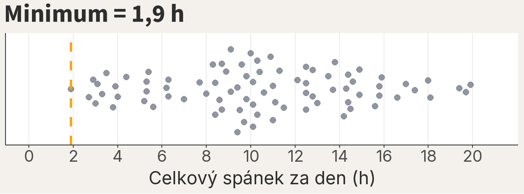

**Maximum**

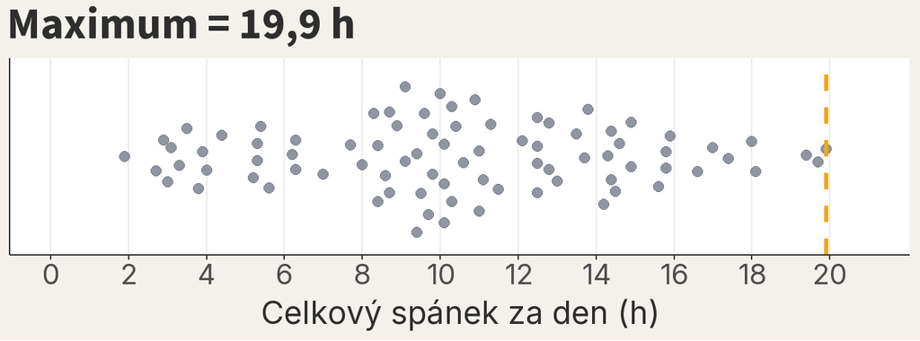

Minimum a maximum popisují pozorovaný rozsah, ale silně závisí na jediném nejkrajnějším řádku.

### 7.3 Aritmetický průměr

Aritmetický průměrSoučet hodnot vydělený jejich počtem; nejběžnější míra polohy (střední hodnoty). (anglicky *mean*) získáme tak, že sečteme všechny hodnoty a součet vydělíme jejich počtem.

Nejdříve slovy:

$$\text{průměrná doba spánku}
=
\frac{\text{součet dob spánku}}{\text{počet druhů}}$$

V malém příkladu dosadíme všechny hodnoty z tabulky:

$$\begin{align}
\text{průměrná doba spánku}
&=
\frac{ 2{,}9 + 3{,}8 + 4 + 8 + 8{,}4 + 9{,}1 + 9{,}7 + 10{,}1 + 12{,}5}{9}
\\
&=
\frac{68{,}5}{9}
\\
&=
7{,}61\ \text{h}
\end{align}$$

Obecný zápis je:

$$\overline{x}
=
\frac{1}{n}
\sum_{i=1}^{n}x_i$$

Zde:

- $x_i$ je hodnota $i$-tého pozorování;
- $n$ je počet pozorování;
- $\sum$ znamená součet všech hodnot;
- $\overline{x}$ je průměr.

```r
# Průhledný výpočet: součet dělený počtem.
sum(vec_maly_spanek) / length(vec_maly_spanek)
```

```
[1] 7.611111
```

```r
# Stejný výsledek jednou funkcí.
mean(vec_maly_spanek)
```

```
[1] 7.611111
```

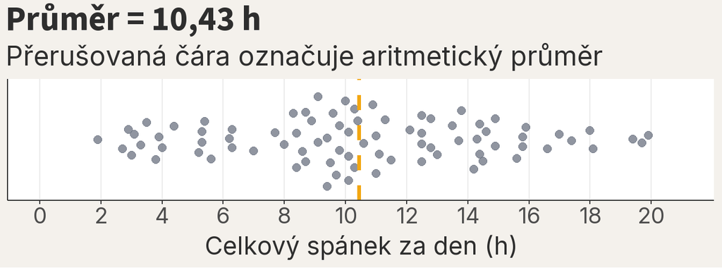

Každá hodnota aritmetický průměr ovlivňuje. Proto se průměr posouvá směrem k velmi vzdáleným hodnotám.

### 7.4 Prostřední hodnota seřazených dat

MediánHodnota rozdělující seřazená data na dvě stejně početné poloviny; 50. percentil. (anglicky *median*) je prostřední hodnota seřazených dat. Polovina hodnot leží nejvýše na jeho úrovni a polovina nejméně na jeho úrovni.

Nejdříve vztah zapíšeme pouze slovy:

$$\text{medián doby spánku}
=
\text{prostřední hodnota seřazených dob spánku}$$

V malém příkladu máme lichý počet hodnot. Prostřední je pátá:

$$2{,}9,\ 3{,}8,\ 4,\ 8,
\ \boxed{8{,}4},
\ 9{,}1,\ 9{,}7,\ 10{,}1,\ 12{,}5$$

Teprve nyní zápis zobecníme. Pro lichý počet $n$ je medián hodnotou na pozici:

$$\widetilde{x}
=
x_{\left(\frac{n+1}{2}\right)}$$

Zde:

- $x$ označuje sledovanou číselnou proměnnou;
- $x_{(i)}$ označuje $i$-tou hodnotu po seřazení;
- $n$ je počet hodnot;
- $\widetilde{x}$ je medián.

```r
median(vec_maly_spanek)
```

```
[1] 8.4
```

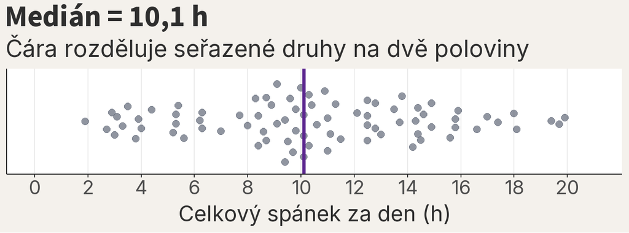

### 7.5 Průměr a medián: návrat k titulku

Nyní máme oba nástroje, které vytvořily úvodní titulky. Podívejme se na hmotnosti všech zastoupených druhů.

**Původní osa**

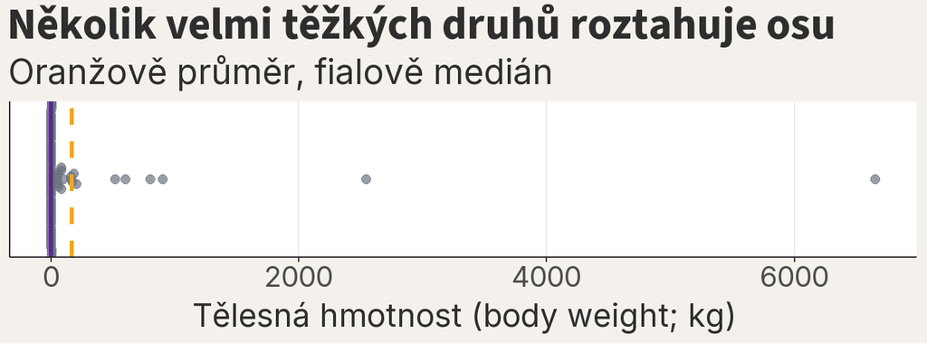

**Přiblížení pomocí logaritmické osy**

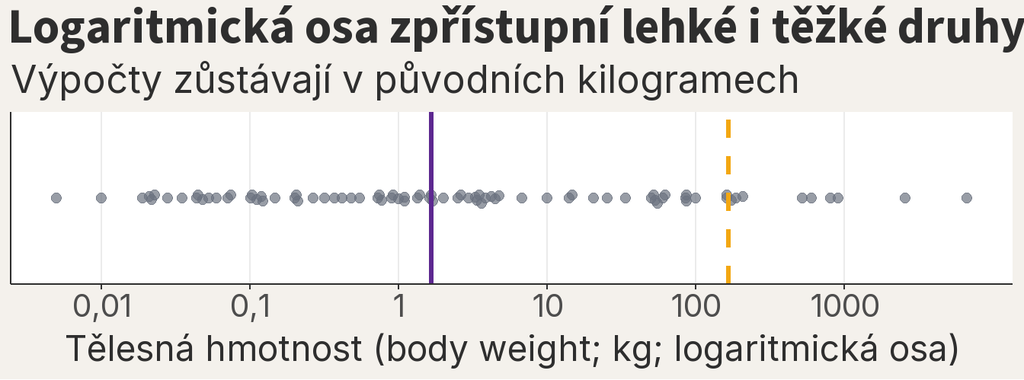

Na původní ose vidíme, že většina druhů leží blízko nuly ve srovnání s několika velmi těžkými druhy. Logaritmická osa pouze mění rozestupy na grafu, aby byly body čitelné; průměr i medián jsou stále vypočtené z kilogramů.

- Průměr hmotnosti je **166 kg**.
- Medián hmotnosti je **1,67 kg**.

Obě čísla jsou vypočtena správně. Průměr ale silně posunulo několik velmi těžkých druhů. Medián lépe popisuje prostřední řádek této výrazně asymetrické tabulky.

**DůležitéVyřešení úvodního hlasování**

Nejpřesnější odpověď byla **C) Obě čísla mohou být vypočtena správně.** Správný výpočet však ještě nezaručuje poctivý titulek. Musíme také uvést, jaké shrnutí jsme použili, jak vypadá graf a co představuje jeden řádek.

**TipDoplňující: kdy může být průměr užitečnější?**

PrůměrSoučet hodnot vydělený jejich počtem; nejběžnější míra polohy (střední hodnoty). je přirozený pro přibližně symetrická číselná data bez mimořádně vzdálených hodnot a je základním stavebním kamenem mnoha statistických modelů. MediánHodnota rozdělující seřazená data na dvě stejně početné poloviny; 50. percentil. je odolnější vůči odlehlým pozorovánímHodnota, která se výrazně odlišuje od ostatních pozorování; může být způsobena chybou měření nebo jít o skutečně extrémní případ. a často lépe popisuje střed silně asymetrických dat. Volba není soutěž mezi „dobrou“ a „špatnou“ statistikou; musí odpovídat grafu a otázce.

### 7.6 Percentily a kvartily

**Percentil (anglicky *percentile*)** je hodnota, pod níž leží určitý podíl seřazených dat. Několik percentilů má vlastní názvy; kvartilyHodnota, pod níž leží určený podíl seřazených dat; medián je 50% kvantil. dělí seřazená data na čtyři části:

- 0. percentil je minimum;
- 25. percentil je dolní kvartil Q1;
- 50. percentil je medián;
- 75. percentil je horní kvartil Q3;
- 100. percentil je maximum.

```r
quantile(
  x = vec_maly_spanek,
  probs = c(0, 0.25, 0.50, 0.75, 1)
)
```

```
  0%  25%  50%  75% 100%
 2.9  4.0  8.4  9.7 12.5
```

*Najděte v následujícím grafu prostřední čáru a pásmo mezi Q1 a Q3. Kolik hodnot by přibližně mělo ležet uvnitř pásma?*

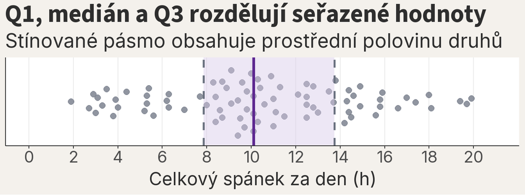

**TipDoplňující: proč kvartil nemusí být přímo v datech?**

U malého souboru může požadovaná procentní pozice ležet mezi dvěma pozorovanými hodnotami. R pak podle zvolené metody provede interpolaci. Proto kvartil nemusí být přesně jednou z hodnot v tabulce. Funkce `quantile()` nabízí více metod pomocí argumentu `type`; pro tento úvod ponecháváme výchozí nastavení.

### 7.7 Prostřední polovina hodnot

Medián popisuje polohu středu, nikoli šířku dat. Mezikvartilové rozpětí (IQR)Rozdíl mezi 3. kvartilem (Q3) a 1. kvartilem (Q1); pokrývá prostředních 50 % dat a je robustní vůči odlehlým pozorováním. (anglicky *interquartile range*) je vzdálenost mezi horním a dolním kvartilem.

Nejdříve slovy:

$$\text{mezikvartilové rozpětí doby spánku}
=
\text{horní kvartil doby spánku}
-
\text{dolní kvartil doby spánku}$$

V malém příkladu nejprve znovu ukážeme všech devět seřazených hodnot. Dolní a horní kvartil jsou zde třetí a sedmá hodnota:

$$2{,}9,\ 3{,}8,
\ \boxed{4{,}0}_{Q_1},
\ 8,\ 8{,}4,\ 9{,}1,
\ \boxed{9{,}7}_{Q_3},
\ 10{,}1,\ 12{,}5$$

Teprve potom odečteme jejich hodnoty:

$$\begin{align}
\text{IQR}
&=
9{,}7
-
4{,}0
\\
&=
5{,}7\ \text{h}
\end{align}$$

Obecný zápis je:

$$\text{IQR}
=
Q_3-Q_1$$

Zde $Q_1$ označuje dolní kvartil a $Q_3$ horní kvartil. IQR popisuje rozsah prostřední poloviny hodnot.

```r
quantile(
  x = vec_maly_spanek,
  probs = c(0.25, 0.75)
)
```

```
25% 75%
4.0 9.7
```

```r
IQR(vec_maly_spanek)
```

```
[1] 5.7
```

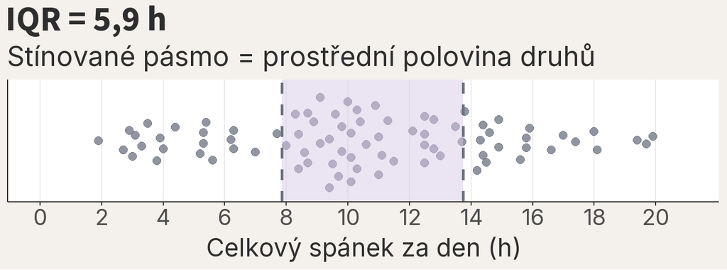

### 7.8 Od středu k variabilitě

Nyní známe minimum, maximum, průměr, medián, kvartily a IQR. Následující dva malé soubory jsou **záměrně sestavené didaktické příklady**, nikoli další pozorování z `msleep`. Jejich průměr je stejný:

```r
vec_spanek_a <-
  c(8, 9, 9, 10, 10, 10, 11, 11, 12)

vec_spanek_b <-
  c(6, 6, 8, 8, 10, 12, 12, 14, 14)

mean(vec_spanek_a)
```

```
[1] 10
```

```r
mean(vec_spanek_b)
```

```
[1] 10
```

*Nejdříve graf sami popište: kde leží hodnoty a v čem se oba soubory liší?*

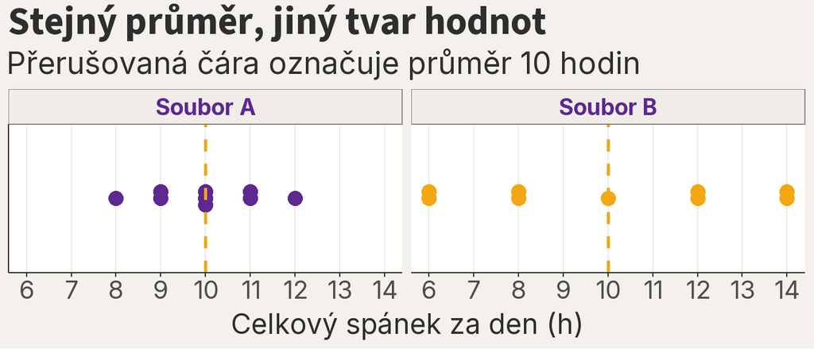

Soubor A je soustředěný kolem 10 hodin. Soubor B má více hodnot na obou okrajích a méně hodnot poblíž středu. Stejný průměr tuto odlišnost skryl.

**QuestionPotřebujeme ještě jedno číslo**

Jak bychom jedním číslem popsali vzdálenosti **všech hodnot od průměru**? Odpověď budeme hledat v následující části.

### 7.9 Jak daleko hodnoty leží od středu

Průměr popsal střed. Nyní potřebujeme říci, jak moc jsou hodnoty **rozptýlené kolem průměru**. Začneme vzdáleností každé hodnoty od průměru.

Nejdříve slovy:

$$\text{odchylka doby spánku druhu}
=
\text{doba spánku druhu}
-
\text{průměrná doba spánku}$$

Na grafu je odchylka vidět jako úsek od průměru k hodnotě každého druhu. Fialové úseky vedou pod průměr, oranžové nad něj.

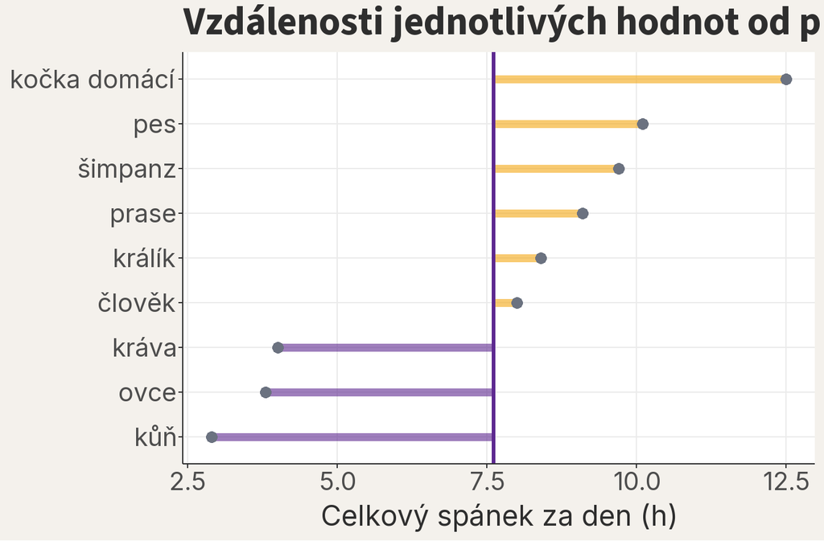

**TipExtra: od odchylek k součtu čtverců, rozptylu a SD**

Tabulka propojuje každou hodnotu s jejím místem v dalším výpočtu:

| Druh | Spánek (h) | Odchylka od průměru (h) | Čtverec odchylky (h²) |
| --- | --- | --- | --- |
| kůň | 2.9 | -4.71 | 22.19 |
| ovce | 3.8 | -3.81 | 14.52 |
| kráva | 4.0 | -3.61 | 13.04 |
| člověk | 8.0 | 0.39 | 0.15 |
| králík | 8.4 | 0.79 | 0.62 |
| prase | 9.1 | 1.49 | 2.22 |
| šimpanz | 9.7 | 2.09 | 4.36 |
| pes | 10.1 | 2.49 | 6.19 |
| kočka domácí | 12.5 | 4.89 | 23.90 |

Například u kočky domácí dosadíme hodnotu z grafu a průměr:

$$\begin{align}
\text{odchylka spánku kočky domácí}
&=
12,5
-
7{,}61
\\
&=
4,89\ \text{h}
\end{align}$$

Obecný zápis odchylky je:

$$e_i=x_i-\overline{x}$$

Zde $e_i$ označuje odchylku $i$-té hodnoty od průměru. Kladné a záporné odchylky se při prostém součtu vyruší: zde dávají po zaokrouhlení 0,00 h. Proto je umocníme na druhou a sečteme. Výsledek se nazývá **součet čtverců** (anglicky *sum of squares*, SS).

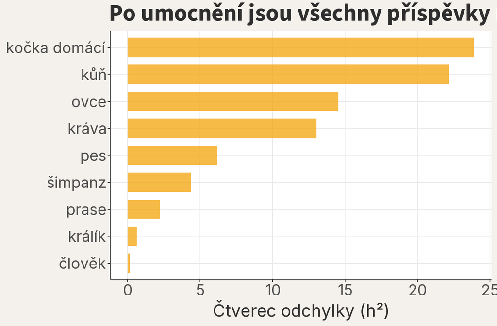

V tomto souboru přispívá k součtu čtverců nejvíce **kočka domácí**: její čtverec odchylky je 23,90 h². Nejde o chybu; kočka jen leží ze všech devíti druhů nejdále od průměru.

$$\begin{align}
\text{součet čtverců odchylek}
&=
22{,}19 + 14{,}52 + 13{,}04 + 0{,}15 + 0{,}62 + 2{,}22 + 4{,}36 + 6{,}19 + 23{,}90
\\
&=
87{,}21\ \text{h}^2
\end{align}$$

Obecně:

$$\text{SS}
=
\sum_{i=1}^{n}
\left(x_i-\overline{x}\right)^2$$

Výběrový rozptylPrůměr čtverců odchylek od průměru; míra variability dat. Odmocnina rozptylu je směrodatná odchylka. (anglicky *sample variance*) získáme vydělením součtu čtverců počtem hodnot minus jedna. Když máme jedinou hodnotu, její průměr je ona sama a odchylka je vždy nula: o skutečné proměnlivosti tak nic nezjistíme. U dvou hodnot po určení průměru stačí znát jednu odchylku, protože druhá musí být opačná. Po odhadu průměru tedy zbývá o jednu nezávislou odchylku méně; tím si vysvětlíme dělitele `n - 1` bez formální definice stupňů volnosti.

Nejdříve slovy:

$$\text{výběrový rozptyl doby spánku}
=
\frac{\text{součet čtverců odchylek}}{\text{počet druhů}-1}$$

V malém příkladu:

$$\begin{align}
\text{výběrový rozptyl doby spánku}
&=
\frac{87{,}21}{9-1}
\\
&=
\frac{87{,}21}{8}
\\
&=
10{,}90\ \text{h}^2
\end{align}$$

Obecně:

$$s^2
=
\frac{1}{n-1}
\sum_{i=1}^{n}
\left(x_i-\overline{x}\right)^2$$

Rozptyl má čtvercové jednotky, zde hodiny na druhou. Abychom se vrátili k hodinám, vezmeme odmocninu. Tím získáme směrodatnou odchylku (SD)Odmocnina rozptylu; vyjadřuje průměrnou vzdálenost hodnot od průměru ve stejných jednotkách jako původní data. (anglicky *standard deviation*).

Nejdříve slovy:

$$\text{směrodatná odchylka doby spánku}
=
\sqrt{\text{výběrový rozptyl doby spánku}}$$

V malém příkladu:

$$\begin{align}
\text{směrodatná odchylka doby spánku}
&=
\sqrt{10{,}90}
\\
&=
3{,}30\ \text{h}
\end{align}$$

Obecně:

$$s=\sqrt{s^2}$$

Zde $s^2$ označuje výběrový rozptyl a $s$ směrodatnou odchylku. SD má stejné jednotky jako původní proměnná.

```r
# Výběrový rozptyl v hodinách na druhou.
var(vec_maly_spanek)
```

```
[1] 10.90111
```

```r
# Směrodatná odchylka v hodinách.
sd(vec_maly_spanek)
```

```
[1] 3.301683
```

Směrodatná odchylka (SD) vyjadřuje, jak rozptýlené jsou hodnoty kolem průměru, ve stejných jednotkách jako původní měření. Pro doby spánku ji spočítáme v R pomocí `sd(vec_maly_spanek)`. Podrobný výpočet přes součet čtverců a rozptyl je v rámečku Extra.

**TipDoplňující: SD není standardní chyba**

SD popisuje, jak se od sebe liší **pozorované hodnoty** — zde doby spánku jednotlivých zastoupených druhů. Standardní chybaMíra přesnosti odhadu parametru (typicky průměru) z dat; udává, jak moc by se odhadnutý parametr lišil při opakovaném vzorkování ze stejné populace. (SE) bude později popisovat něco jiného: jak přesný je **odhadČíslo vypočtené z pozorovaných dat jako přiblížení neznámé vlastnosti nebo parametru; jiný srovnatelný výběr může dát jiný odhad.**, například odhad průměru nebo sklonuParametr lineárního modelu udávající, o kolik se změní odezva, pokud prediktor vzroste o jednu jednotku (při zachování ostatních prediktorů). modelu.

Velká SD tedy neznamená automaticky chybný výpočet a malá SD neznamená automaticky přesný odhad pro celou populaci. Zatím stačí držet dvě otázky odděleně: **jak rozdílná jsou pozorování?** odpovídá SD; **jak přesný je náš odhad?** začne odpovídat SE v lekci o nejistotě odhadu.

### 7.10 SD jako vzdálenost na grafu

Na grafu můžeme kolem průměru vyznačit vzdálenost jedné SD na obě strany. Pásmo není automatickým pravidlem, kolik bodů „musí“ obsahovat. Ukazuje měřítko rozptýlení hodnot kolem průměru.

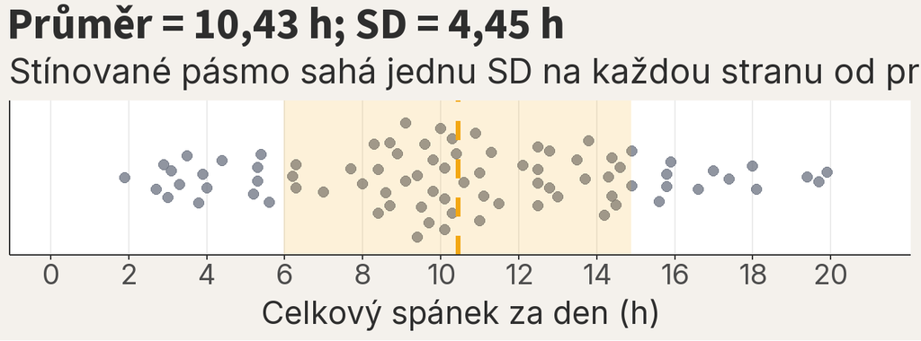

### 7.11 Stejná průměrná mzda, jiná SD

Význam SD si lze snadno představit u měsíčních mezd. Následující dvě firmy jsou **smyšlený příklad**: v obou je průměrná mzda 50 tisíc Kč, ale jednotlivé mzdy se kolem stejného průměru rozkládají jinak.

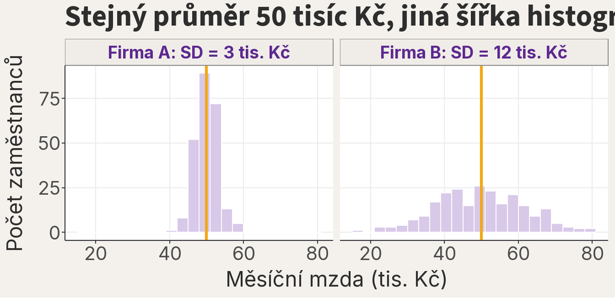

Ve firmě A leží mzdy blíže průměru a SD je 3 tisíce Kč. Ve firmě B jsou mzdy rozptýlenější a SD je 12 tisíc Kč. **Vyšší SD znamená větší typickou vzdálenost hodnot od průměru**, nikoli automaticky vyšší nebo nižší mzdu.

**TipDoplňující: co může míra rozptýlení znamenat biologicky?**

Představte si dvě populace ptáků se stejnou průměrnouSoučet hodnot vydělený jejich počtem; nejběžnější míra polohy (střední hodnoty). délkou křídla. Jedna má malou SDOdmocnina rozptylu; vyjadřuje průměrnou vzdálenost hodnot od průměru ve stejných jednotkách jako původní data., druhá velkou. První je z hlediska délky křídel uniformnější; druhá variabilnějšíObecný termín pro rozsah, v němž se hodnoty proměnné liší od sebe navzájem; kvantifikuje se pomocí rozptylu, SD, IQR nebo rozsahu.. Příčinou mohou být například rozdílné podmínky prostředí, smíšené věkové skupiny, pohlavní dimorfismus nebo chyba měření. SD sama příčinu neodhalí, ale upozorní, že biologická variabilita stojí za další otázku.

### 7.12 Které dvojice souhrnů patří k sobě?

| Míra středu | Míra variability | Kdy je dvojice často užitečná |
| --- | --- | --- |
| průměr (*mean*) | směrodatná odchylka (*standard deviation*) | přibližně symetrická číselná data bez výrazně vzdálených hodnot |
| medián (*median*) | IQR (*interquartile range*) | asymetrická číselná data nebo data s výrazně vzdálenými hodnotami |

Nejde o mechanické pravidlo. Nejprve vždy prohlédněte graf a zvažte biologický význam.

## 8 Statistiky jako vizualizace: stavíme graf ze souhrnů

Minimum, kvartilyHodnota, pod níž leží určený podíl seřazených dat; medián je 50% kvantil., mediánHodnota rozdělující seřazená data na dvě stejně početné poloviny; 50. percentil. a IQRRozdíl mezi 3. kvartilem (Q3) a 1. kvartilem (Q1); pokrývá prostředních 50 % dat a je robustní vůči odlehlým pozorováním. již známe. Nyní z nich sestavíme krabicový graf (boxplot)Graf, jehož krabice sahá od Q1 do Q3 a obsahuje medián; vousy vymezují hodnoty podle zvoleného pravidla a body za nimi upozorňují na možná odlehlá pozorování. krok za krokem, aby žádná jeho část nebyla záhadným symbolem. Pokračujeme s tělesnou hmotností: správně vypočtený titulek tak můžeme doplnit grafem, který ukáže celé rozděleníPopis toho, jaké hodnoty proměnná nabývá a jak často se vyskytují; může jít o pozorované rozdělení dat nebo o teoretické pravděpodobnostní rozdělení. zastoupených druhů.

### 8.1 Krok 1: jednotlivé hodnoty a medián

Začneme bodovým grafem a přidáme čáru na pozici mediánu. Každý bod stále vidíme.

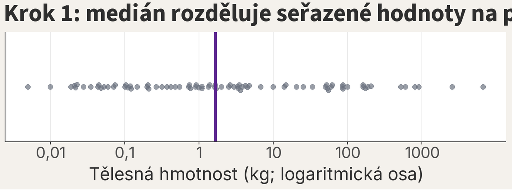

### 8.2 Krok 2: krabice je IQR

Obdélník od Q1 do Q3 obsahuje prostřední polovinu hodnot. Jeho šířka je IQR.

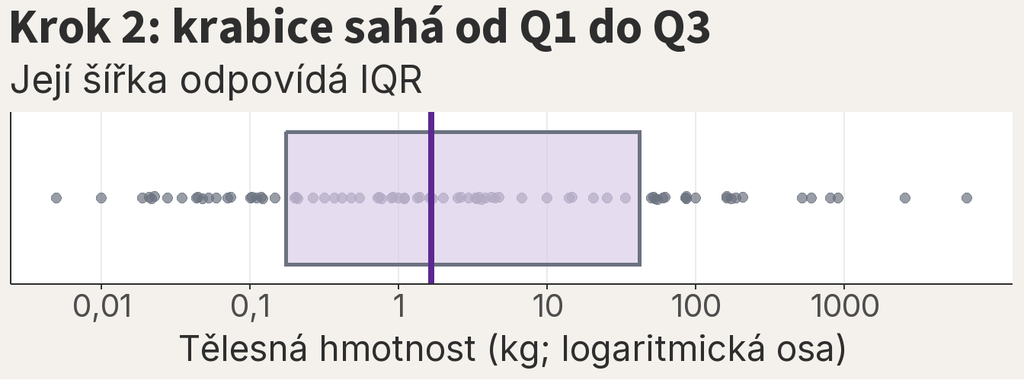

### 8.3 Krok 3: vousy a body za nimi

Od hran krabice odměříme vzdálenost 1,5násobku IQR. Vous končí na nejkrajnější skutečně pozorované hodnotě, která ještě leží uvnitř této hranice. Hodnoty za vousy se vykreslí samostatně jako možná odlehlá pozorováníHodnota, která se výrazně odlišuje od ostatních pozorování; může být způsobena chybou měření nebo jít o skutečně extrémní případ.. V předchozích krocích byly všechny původní body šedé; od tohoto kroku zobrazujeme body za hranicemi samostatně šedě. Chceme je vidět, ale nejsou automaticky hlavním sdělením grafu.

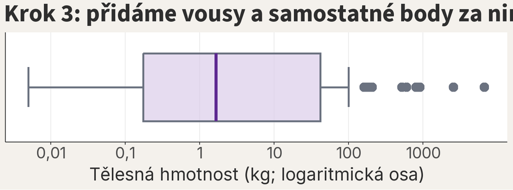

**TipDoplňující: jak určíme bod za vousy?**

Nejdříve pravidlo zapíšeme slovy:

$$\begin{align}
\text{dolní hranice}
&=
\text{dolní kvartil}
-
1{,}5
\times
\text{IQR}
\\
\text{horní hranice}
&=
\text{horní kvartil}
+
1{,}5
\times
\text{IQR}
\end{align}$$

Pro tělesnou hmotnost dosadíme hodnoty z našeho souboru:

$$\begin{align}
\text{dolní hranice}
&=
0{,}174
-
1{,}5
\times
41{,}58
\\
&=
-62{,}19\ \text{kg}
\\
\text{horní hranice}
&=
41{,}75
+
1{,}5
\times
41{,}58
\\
&=
104{,}1\ \text{kg}
\end{align}$$

Obecně:

$$\begin{align}
L &= Q_1 - 1{,}5 \times \text{IQR}
\\
U &= Q_3 + 1{,}5 \times \text{IQR}
\end{align}$$

Zde $L$ označuje dolní hranici, $U$ horní hranici, $Q_1$ dolní kvartil a $Q_3$ horní kvartil. Bod menší než $L$ nebo větší než $U$ se vykreslí samostatně. Vous nekončí přímo na vypočtené hranici, ale na nejkrajnější **skutečně pozorované hodnotě**, která ještě leží uvnitř hranice.

**UpozorněníBod za vousy není automaticky chyba**

Pravidlo 1,5 × IQRRozdíl mezi 3. kvartilem (Q3) a 1. kvartilem (Q1); pokrývá prostředních 50 % dat a je robustní vůči odlehlým pozorováním. označuje hodnotu k bližšímu prozkoumání. Bod může být překlep, zvláštní měření nebo zcela reálný biologický druh. O jeho významu rozhodujeme podle zdroje dat a biologického kontextu, ne podle grafu samotného.

Ve všech následujících krabicových grafech označujeme jako možné odlehlé hodnoty **stejné druhy podle hranic vypočtených v původních kilogramech**. Logaritmická osa mění pouze rozestupy mezi body, nikoli pravidlo pro jejich označení.

### 8.4 Výsledný krabicový graf

R sestaví stejné prvky jedním příkazem.

**Graf**

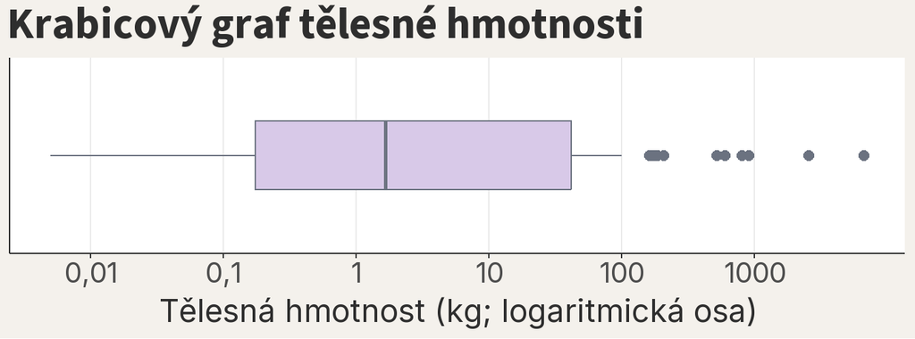

**Kód v R**

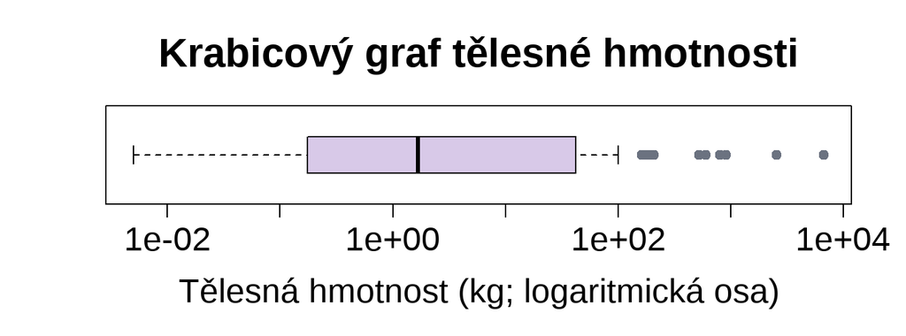

```r
# Vytvoříme vodorovný krabicový graf.
boxplot(
  x = vec_hmotnost_kg,
  horizontal = TRUE,
  log = "x",
  col = "#D8C9E8",
  outpch = 21,
  outcol = "#6B7280",
  outbg = "#6B7280",
  xlab = "Tělesná hmotnost (kg; logaritmická osa)",
  main = "Krabicový graf tělesné hmotnosti"
)
```

| Prvek | Co znamená |
| --- | --- |
| čára uvnitř krabice | medián, tedy 50. percentil |
| levý a pravý okraj krabice | Q1 a Q3 |
| šířka krabice | IQR, tedy prostřední polovina hodnot |
| vousy | nejkrajnější hodnoty uvnitř hranice 1,5 × IQR |
| samostatné body | možné odlehlé hodnoty za vousy |

### 8.5 Když chceme vidět tvar: houslový graf

**Houslový graf** (anglicky *violin plot*) zachovává hladký obrys rozděleníPopis toho, jaké hodnoty proměnná nabývá a jak často se vyskytují; může jít o pozorované rozdělení dat nebo o teoretické pravděpodobnostní rozdělení.: čím je „housle“ v určité části širší, tím více hodnot se v této oblasti soustředí.

Krabicový graf rychle ukáže medián, kvartily a možné odlehlé hodnoty, ale neukáže, zda se hodnoty hromadí v jednom nebo několika shlucích. V takové situaci může být houslový graf informativnější. Úzký boxplot uvnitř ponechává známé souhrny a obrys kolem něj doplňuje tvar dat.

Obecný základní zápis může vypadat takto:

```r
# Jedna housle zobrazí rozdělení hodnot v každé skupině.
ggplot2::ggplot(
  data = data_mereni,
  mapping = ggplot2::aes(
    x = skupina,
    y = hodnota
  )
) +
  ggplot2::geom_violin()
```

Názvy `data_mereni`, `skupina` a `hodnota` nahradíme názvy z vlastních dat.

*Kde je housle nejširší? Dokázali byste tuto informaci vyčíst ze samotného krabicového grafu? Jak daleko od sebe leží průměrSoučet hodnot vydělený jejich počtem; nejběžnější míra polohy (střední hodnoty). a medián?*

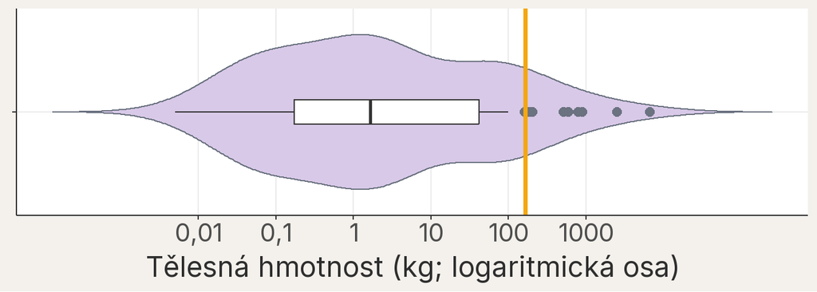

Oranžová svislá čára označuje aritmetický průměr, čára uvnitř krabice medián a šedé body možné odlehlé hodnoty.

**TipDoplňující: úplný kód kombinovaného grafu**

Tento kód navazuje na výpočet kvartilů, vousů, možných odlehlých hodnot a průměru v předchozí části.

```r
# Přidáme ke tvaru rozdělení krabici, body za vousy a průměr.
ggplot2::ggplot(
  data = data_hmotnost,
  mapping = ggplot2::aes(x = hmotnost_kg, y = "")
) +
  ggplot2::geom_violin(
    orientation = "y", trim = FALSE,
    fill = "#D8C9E8", color = "#6B7280"
  ) +
  ggplot2::geom_boxplot(
    data = data_boxplot_hmotnost,
    mapping = ggplot2::aes(
      y = skupina,
      xmin = vous_dolni, xlower = q1, xmiddle = median,
      xupper = q3, xmax = vous_horni
    ),
    stat = "identity", orientation = "y", width = 0.14,
    fill = "white", inherit.aes = FALSE
  ) +
  ggplot2::geom_point(
    data = data_odlehle_hmotnost,
    mapping = ggplot2::aes(x = hmotnost_kg, y = ""),
    inherit.aes = FALSE, shape = 21,
    color = "#6B7280", fill = "#6B7280", size = 2.4
  ) +
  ggplot2::geom_vline(
    xintercept = prumer_hmotnost,
    color = "#F3A712", linewidth = 1.3
  ) +
  ggplot2::scale_x_log10() +
  ggplot2::labs(
    x = "Tělesná hmotnost (kg; logaritmická osa)",
    y = NULL
  )
```

Průměr přidáváme pouze do kombinovaného grafu, abychom vedle tvaru rozdělení viděli oba způsoby popisu středu. Houslový graf ale také vyhlazuje data. U malého souboru proto mohou být poctivější jednotlivé body; žádný typ grafu není nejlepší ve všech situacích.

**TipDoplňující: co tento souhrnný graf skrývá?**

Krabicový graf je kompaktní a dobře se skládá vedle dalších skupin, ale skrývá jednotlivé hodnoty i podrobný tvar rozdělení. Dva různé soubory mohou mít stejný boxplot. Když je to možné, doplňte jej body, houslovým grafem nebo se vraťte k histogramuGraf zobrazující rozdělení hodnot numerické proměnné: hodnoty jsou seřazeny do tříd, výška sloupce udává četnost v dané třídě..

## 9 Typy proměnných: zobecnění na konci

Doteď jsme sledovali hlavně jednu proměnnouVlastnost zaznamenaná u pozorování, která může mezi pozorováními nabývat různých hodnot, například druh, délka nebo počet.: dobu spánku savce za den. Teprve teď máme dost zkušeností, abychom si položili obecnější otázku: **jaký druh informace proměnná nese?**

U jednoho savce bychom mohli zaznamenat například:

- dobu spánku v hodinách;
- hmotnost v kilogramech;
- počet pozorovaných jedinců;
- typ potravy;
- velikostní kategorii.

Tyto údaje nelze popisovat ani zobrazovat všechny stejným způsobem. Stejné zapsané číslo totiž může znamenat něco úplně jiného:

Nejprve proto určujeme pozorovací jednotkuEntita nebo děj, o kterém jedno pozorování nese informace, například jedinec, plocha, vzorek vody nebo jedna erupce.: koho nebo co jeden řádek reprezentuje.

| Zápis | Co znamená | Typ proměnné |
| --- | --- | --- |
| 37,0 | tělesná teplota 37,0 °C | numerická spojitáNumerická proměnná, která může v principu nabývat libovolné hodnoty v určitém intervalu, například délka, hmotnost nebo čas. |
| 37 | počet rostlin na ploše | numerická diskrétníNumerická proměnná s oddělenými, spočetnými možnými hodnotami, například počet jedinců nebo počet událostí. |
| 37 | číselný kód lokality | kategoriální nominálníKategoriální proměnná, jejíž kategorie nemají přirozené pořadí, například druh, ostrov nebo barva. |
| 3 | hodnocení na škále 1–5 | kategoriální ordinálníKategoriální proměnná s přirozeně seřazenými kategoriemi, jejichž vzájemné vzdálenosti však nemusí být stejné nebo známé. |

**PoznámkaTyp proměnné neurčuje vzhled hodnoty**

O typu proměnné rozhoduje **význam hodnot a způsob jejich vzniku**, ne to, zda jsou v tabulce zapsány číslem nebo slovem.

**PoznámkaStatistický typ není totéž co třída objektu v R**

R popisuje technickou podobu objektu pomocí `class()` a `typeof()`. Funkce `str()` ukáže jeho stručnou strukturu a několik hodnot. Tyto kontroly jsou velmi užitečné, ale samy nerozhodnou, zda je proměnná spojitá, diskrétní, nominální nebo ordinální. K tomu stále potřebujeme vědět, co hodnoty znamenají a jak vznikly.

Při určování typu si zkuste doplnit větu:

> Jeden řádek představuje ___ a tato proměnná říká ___.

Tím se zároveň vracíte k pozorovací jednotce. Počet druhů v jednom řádu může být například vlastností lokality, zatímco řád savce je vlastností druhu.

### 9.1 Numerická spojitá proměnná

**Numerická spojitá proměnná** (*continuous numerical variable*; vyhledávací termín *continuous data*) vzniká měřením. Mezi dvěma hodnotami si obvykle umíme představit další možné hodnoty, i když je přístroj zaokrouhlí.

Příklady z reálného světa:

- délka těla nebo listu,
- tělesná hmotnost,
- teplota,
- koncentrace látky,
- doba spánku.

**Jak ji uvidíme v R?**

```r
# Vybereme sloupec s naměřenou dobou spánku.
vec_spanek_h <- ggplot2::msleep[["sleep_total"]]

# Zobrazíme prvních šest hodnot.
head(vec_spanek_h)
```

```
[1] 12.1 17.0 14.4 14.9  4.0 14.4
```

```r
# Zjistíme třídu objektu, jak ji popisuje R.
class(vec_spanek_h)
```

```
[1] "numeric"
```

```r
# Zjistíme, jak jsou hodnoty technicky uložené.
typeof(vec_spanek_h)
```

```
[1] "double"
```

```r
# Získáme stručný přehled o struktuře objektu.
str(vec_spanek_h)
```

```
 num [1:83] 12.1 17 14.4 14.9 4 14.4 8.7 7 10.1 3 ...
```

R tento vektor zobrazí jako `numeric` a technicky jej uloží jako `double`. Z toho ještě nepozná, že jde o spojitou proměnnou. To usuzujeme z významu: doba spánku vznikla měřením a mezi dvěma hodnotami si umíme představit další.

Pro spojitou proměnnou jsme už použili čtyři vhodné grafy: bodový graf, histogramGraf zobrazující rozdělení hodnot numerické proměnné: hodnoty jsou seřazeny do tříd, výška sloupce udává četnost v dané třídě., graf hustoty a krabicový grafGraf, jehož krabice sahá od Q1 do Q3 a obsahuje medián; vousy vymezují hodnoty podle zvoleného pravidla a body za nimi upozorňují na možná odlehlá pozorování..

**Bodový graf**

Ukazuje každé pozorování. Je výborný pro malý až střední soubor.

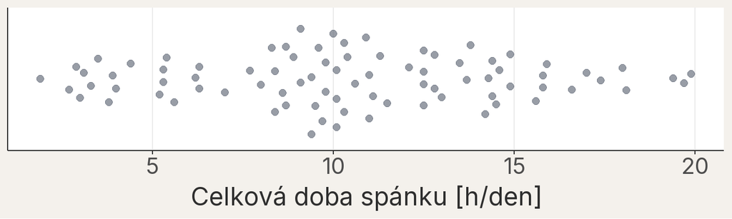

Každá tečka představuje jeden druh savce.

**Histogram**

Sdružuje hodnoty do intervalů. Hodí se, když chceme vidět tvar rozděleníPopis toho, jaké hodnoty proměnná nabývá a jak často se vyskytují; může jít o pozorované rozdělení dat nebo o teoretické pravděpodobnostní rozdělení..

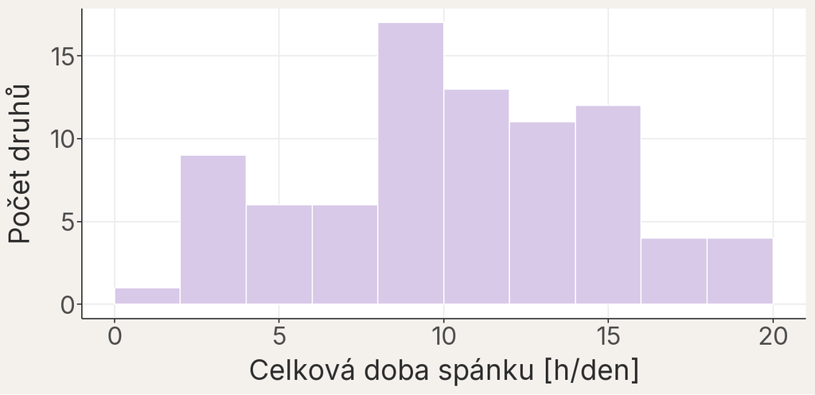

Histogram spojité proměnné; vzhled závisí na šířce košů.

**Graf hustoty**

Nabízí vyhlazený pohled na tvar rozdělení. Vyhlazení je analytické rozhodnutí, nikoli další měření.

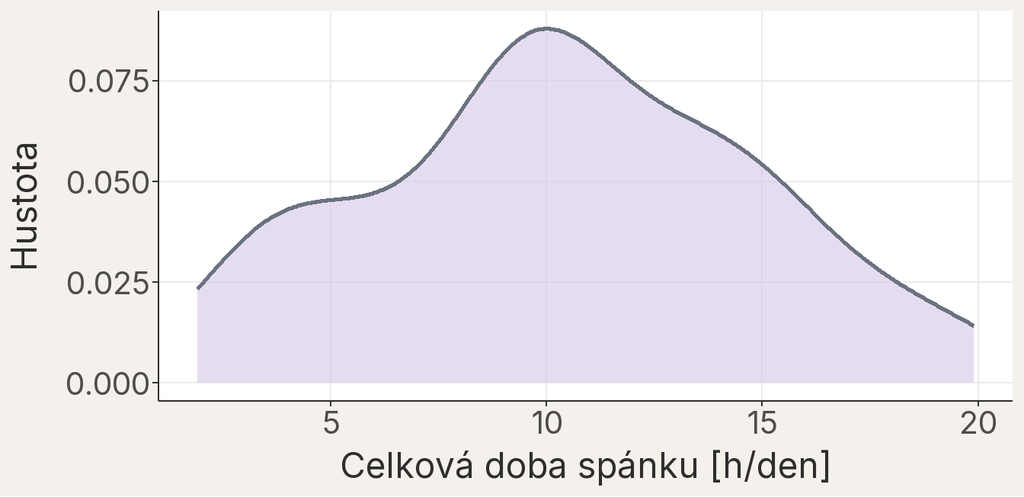

Vyhlazený odhad hustoty spojité proměnné.

**Krabicový graf**

Zhušťuje data do mediánuHodnota rozdělující seřazená data na dvě stejně početné poloviny; 50. percentil., kvartilůHodnota, pod níž leží určený podíl seřazených dat; medián je 50% kvantil., vousů a případných odlehlých pozorováníHodnota, která se výrazně odlišuje od ostatních pozorování; může být způsobena chybou měření nebo jít o skutečně extrémní případ..

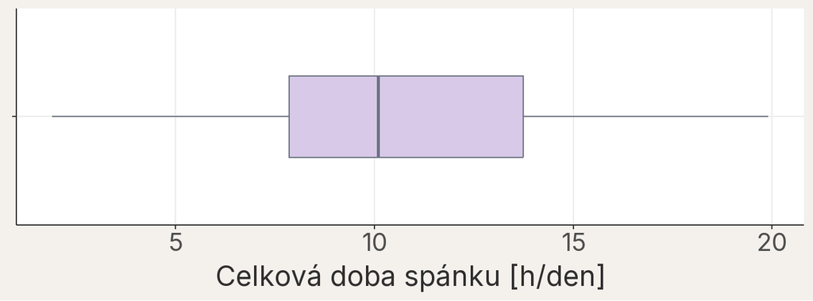

Krabicový graf stejné spojité proměnné.

### 9.2 Numerická diskrétní proměnná

**Numerická diskrétní proměnná** (*discrete numerical variable*, také *count data*) vzniká nejčastěji počítáním. Možné hodnoty jsou oddělené: mezi 4 a 5 mláďaty není 4,6 mláděte.

Příklady:

- počet mláďat,
- počet druhů na lokalitě,
- počet semen,
- počet návštěv květu,
- počet přečtených sekvencí.

Oba počty jsou diskrétní, ale při volbě grafu a souhrnu záleží také na rozsahu možných hodnot a biologické otázce: počet mláďat mívá jen několik hodnot, zatímco počet listů na stromě může být velmi vysoký. Samotný štítek „diskrétní“ nám proto neurčí jeden univerzální graf.

V našem datasetu můžeme změnit pozorovací jednotku a spočítat, kolik druhů zastupuje každý taxonomický řád:

**Jak ji uvidíme v R?**

```r
# Spočítáme druhy v každém taxonomickém řádu.
cetnosti_radu <- table(ggplot2::msleep[["order"]])

# Ponecháme jen vypočtené počty bez názvů řádů.
vec_pocet_druhu <- as.integer(cetnosti_radu)

# Zobrazíme prvních šest počtů.
head(vec_pocet_druhu)
```

```
[1]  1  6 12  3  2  2
```

```r
# Zjistíme třídu objektu, jak ji popisuje R.
class(vec_pocet_druhu)
```

```
[1] "integer"
```

```r
# Zjistíme, jak jsou hodnoty technicky uložené.
typeof(vec_pocet_druhu)
```

```
[1] "integer"
```

```r
# Získáme stručný přehled o struktuře objektu.
str(vec_pocet_druhu)
```

```
 int [1:19] 1 6 12 3 2 2 2 2 2 3 ...
```

R vrátí třídu i způsob uložení `integer`, protože jsme vytvořili vektor celých počtů. Ani `integer` ale automaticky neznamená diskrétní proměnnou: například zaokrouhlená teplota může být také zapsána celým číslem. Rozhodující je, že zde druhy skutečně počítáme.

Takovou četnostPočet výskytů určité hodnoty nebo kategorie v datové sadě; pro kategoriální proměnné je četnost základní deskriptivní statistikou. můžeme zobrazit jako body nebo sloupcový grafGraf kategoriální proměnné, v němž výška nebo délka oddělených sloupců představuje četnosti, podíly nebo jiný souhrn kategorií..

**Bodový graf četností**

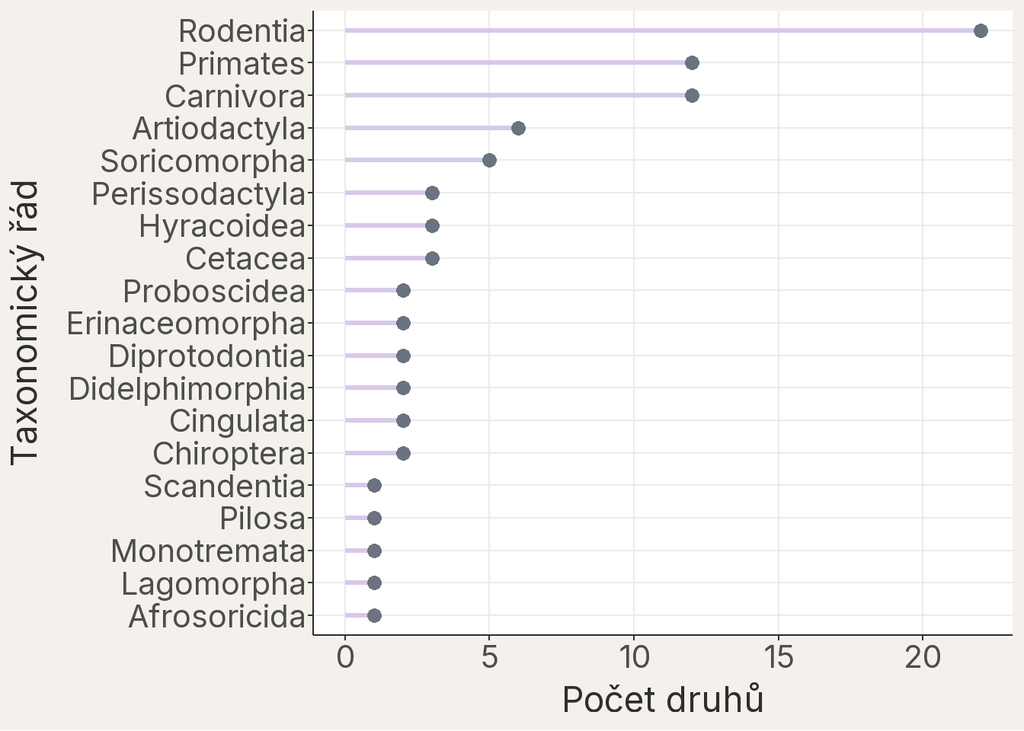

Počet druhů savců zastoupených v jednotlivých taxonomických řádech.

**Sloupcový graf**

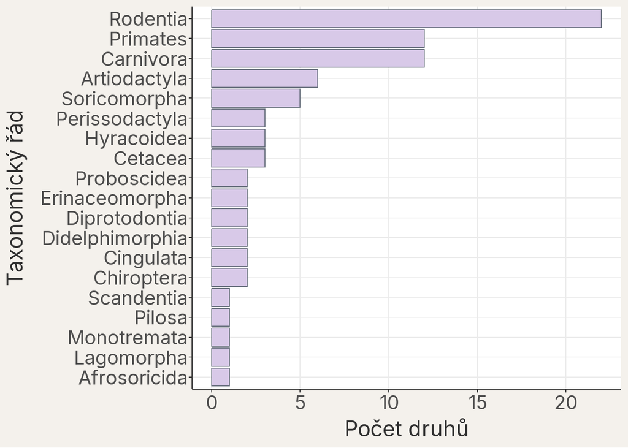

Sloupcový graf týchž počtů.

U diskrétních dat můžeme použít také histogram, ale jeho koše musí respektovat jednotlivé možné hodnoty. PrůměrSoučet hodnot vydělený jejich počtem; nejběžnější míra polohy (střední hodnoty). může být smysluplný i tehdy, když sám není možným pozorováním: průměrný počet mláďat může být 2,4, přestože žádné zvíře nemělo „0,4 mláděte“.